# Otus Machine Learning Course. Homework №8

### Воротников Владимир

### Навигация

1. Basic EDA

Базовый EDA, удаление ненужных столбцов

2. Prepare data

Train-test разбиение, добавление новых признаков, построение базового (baseline) прогноза

3. Modeling

Построение моделей, тюнинг параметров, оценка качества

3.1 Holt-Winters model

3.2 SARIMA

3.3 Linear regression)

3.4 Boosting

3.5 Facebook prophet

4. Conclusion

```python
import numpy as np
import pandas as pd
import seaborn as sns

import matplotlib.pyplot as plt
%matplotlib inline

from IPython.display import display

import warnings
warnings.filterwarnings("ignore")

plt.rcParams["figure.figsize"] = [18, 8]
```

## 1. Basic EDA

```python
data = pd.read_csv('data/metro_itv.csv')
```

```python
data.drop(['rain_1h', 'snow_1h', 'clouds_all', 'weather_main', 'weather_description'], axis=1, inplace=True)
```

```python
data
```

|  | holiday | temp | date_time | traffic_volume |
| --- | --- | --- | --- | --- |
| 0 | None | 288.28 | 2012-10-02 09:00:00 | 5545 |
| 1 | None | 289.36 | 2012-10-02 10:00:00 | 4516 |
| 2 | None | 289.58 | 2012-10-02 11:00:00 | 4767 |
| 3 | None | 290.13 | 2012-10-02 12:00:00 | 5026 |
| 4 | None | 291.14 | 2012-10-02 13:00:00 | 4918 |
| ... | ... | ... | ... | ... |
| 48199 | None | 283.45 | 2018-09-30 19:00:00 | 3543 |
| 48200 | None | 282.76 | 2018-09-30 20:00:00 | 2781 |
| 48201 | None | 282.73 | 2018-09-30 21:00:00 | 2159 |
| 48202 | None | 282.09 | 2018-09-30 22:00:00 | 1450 |
| 48203 | None | 282.12 | 2018-09-30 23:00:00 | 954 |

48204 rows × 4 columns

```python
data.info()
```

```
<class 'pandas.core.frame.DataFrame'>
RangeIndex: 48204 entries, 0 to 48203
Data columns (total 4 columns):
 #   Column          Non-Null Count  Dtype
---  ------          --------------  -----
 0   holiday         48204 non-null  object
 1   temp            48204 non-null  float64
 2   date_time       48204 non-null  object
 3   traffic_volume  48204 non-null  int64
dtypes: float64(1), int64(1), object(2)
memory usage: 1.5+ MB
```

```python
data.nunique()
```

```
holiday              12
temp               5843
date_time         40575
traffic_volume     6704
dtype: int64
```

```python
data.isnull().sum()
```

```
holiday           0
temp              0
date_time         0
traffic_volume    0
dtype: int64
```

```python
data.describe()
```

|  | temp | traffic_volume |
| --- | --- | --- |
| count | 48204.000000 | 48204.000000 |
| mean | 281.205870 | 3259.818355 |
| std | 13.338232 | 1986.860670 |
| min | 0.000000 | 0.000000 |
| 25% | 272.160000 | 1193.000000 |
| 50% | 282.450000 | 3380.000000 |
| 75% | 291.806000 | 4933.000000 |
| max | 310.070000 | 7280.000000 |

### -temperature

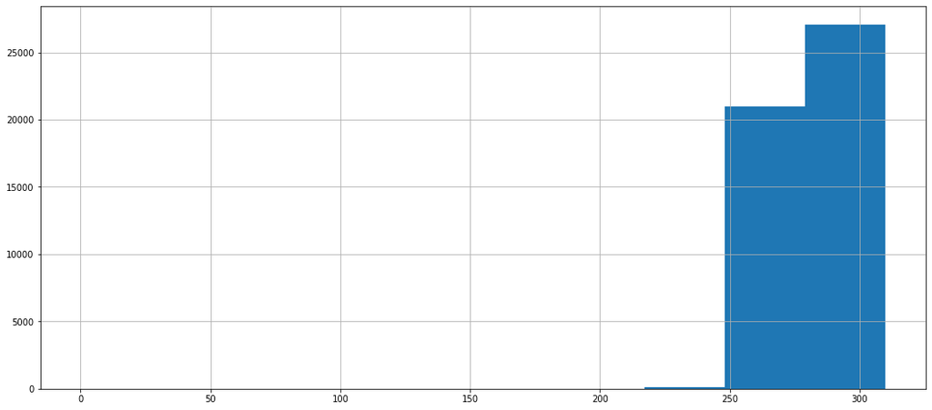

```python
data.temp.hist()
```

```python
data[data.temp==0.0].temp.count()
```

```
10
```

```python
data[data.temp==0.0].temp = data.temp.mean()
```

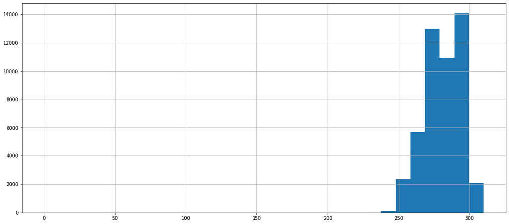

```python
data.temp.hist(bins=30)
```

### -traffic volume

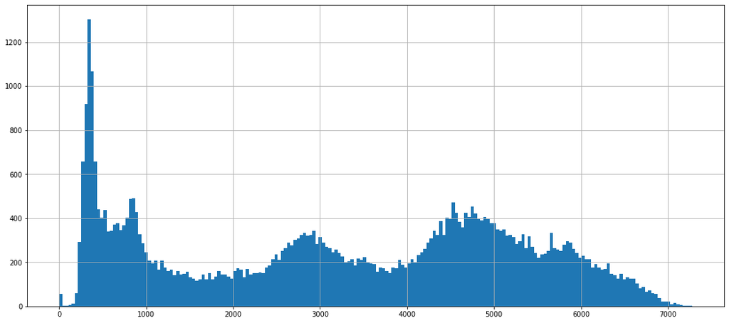

```python
data.traffic_volume.hist(bins=200)
```

```python
data[data.traffic_volume == 0].traffic_volume.count()
```

```
2
```

### -holidays

```python
data.holiday.value_counts()
```

```
None                         48143
Labor Day                        7
New Years Day                    6
Thanksgiving Day                 6
Martin Luther King Jr Day        6
Christmas Day                    6
Columbus Day                     5
Veterans Day                     5
Washingtons Birthday             5
State Fair                       5
Independence Day                 5
Memorial Day                     5
Name: holiday, dtype: int64
```

```python
data.groupby('holiday').traffic_volume.mean()
```

```
holiday
Christmas Day                 827.500000
Columbus Day                  519.400000
Independence Day             1076.000000
Labor Day                    1013.142857
Martin Luther King Jr Day     612.666667
Memorial Day                 1107.600000
New Years Day                1356.000000
None                         3262.852170
State Fair                    634.800000
Thanksgiving Day              933.500000
Veterans Day                  691.400000
Washingtons Birthday          635.200000
Name: traffic_volume, dtype: float64
```

Убираем различие между разными праздниками, делая переменную holiday бинарной

```python
data.loc[data['holiday'] !='None', 'holiday'] = True
data.loc[data['holiday'] =='None', 'holiday'] = False
```

```python
data.holiday.value_counts()
```

```
False    48143
True        61
Name: holiday, dtype: int64
```

### - date and time

```python
data.date_time.value_counts()
```

```
2013-05-19 10:00:00    6
2013-04-18 22:00:00    6
2013-06-01 02:00:00    5
2013-05-20 17:00:00    5
2016-05-27 18:00:00    5
                      ..
2015-09-15 03:00:00    1
2018-01-24 04:00:00    1
2017-02-19 03:00:00    1
2013-04-05 22:00:00    1
2017-05-27 01:00:00    1
Name: date_time, Length: 40575, dtype: int64
```

```python
data[data.date_time=='2013-05-19 10:00:00']
```

|  | holiday | temp | date_time | traffic_volume |
| --- | --- | --- | --- | --- |
| 6162 | False | 287.15 | 2013-05-19 10:00:00 | 3591 |
| 6163 | False | 287.15 | 2013-05-19 10:00:00 | 3591 |
| 6164 | False | 287.15 | 2013-05-19 10:00:00 | 3591 |
| 6165 | False | 287.15 | 2013-05-19 10:00:00 | 3591 |
| 6166 | False | 287.15 | 2013-05-19 10:00:00 | 3591 |
| 6167 | False | 287.15 | 2013-05-19 10:00:00 | 3591 |

```python
data.drop_duplicates(keep='first',inplace=True)
```

Убираем дубликаты и пропуски в шкале времени

```python
datarange = pd.date_range(start='2012-10-02 09:00:00', end='2018-09-30 23:00:00', freq='1h')
data.index = pd.to_datetime(data.date_time)
data = data[~data.index.duplicated()]
data = data.reindex(datarange)
```

```python
data.isnull().sum()
```

```
holiday           11976
temp              11976
date_time         11976
traffic_volume    11976
dtype: int64
```

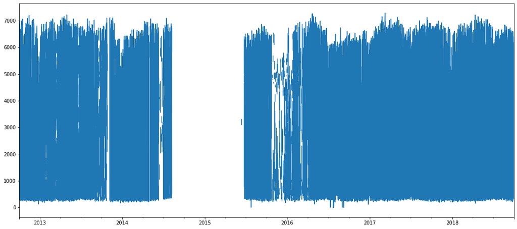

```python
data.traffic_volume.plot()
```

Отбрасываем большую часть данных. Оставляем 2017 год с идеей того, что могут быть какие-то паттерны в зависимости от месяца

```python
data.drop(data[data.index<'2017-01-01 00:00:00'].index,inplace=True)
```

```python
data.isnull().sum()
```

```
holiday           66
temp              66
date_time         66
traffic_volume    66
dtype: int64
```

```python
data.interpolate(inplace=True)
```

```python
data.drop("date_time", axis=1, inplace=True)
```

```python
data.isnull().sum()
```

```
holiday           66
temp               0
traffic_volume     0
dtype: int64
```

```python
is_holiday = data.groupby(data.index.date).holiday.sum()==1
```

```python
datarange = pd.date_range(start='2017-01-01 00:00:00', end='2018-09-30 23:00:00', freq='1h')
is_holiday = is_holiday.reindex(datarange)
is_holiday.fillna(method='ffill', inplace=True)
data['is_holiday'] = is_holiday.replace({True:1, False:0})
data.drop('holiday', axis=1, inplace=True)
data[data.is_holiday==1].count()
```

```
temp              432
traffic_volume    432
is_holiday        432
dtype: int64
```

```python
data.isnull().sum()
```

```
temp              0
traffic_volume    0
is_holiday        0
dtype: int64
```

```python
data
```

|  | temp | traffic_volume | is_holiday |
| --- | --- | --- | --- |
| 2017-01-01 00:00:00 | 269.75 | 1848.0 | 0 |
| 2017-01-01 01:00:00 | 269.95 | 1806.0 | 0 |
| 2017-01-01 02:00:00 | 269.75 | 1211.0 | 0 |
| 2017-01-01 03:00:00 | 269.65 | 794.0 | 0 |
| 2017-01-01 04:00:00 | 269.48 | 500.0 | 0 |
| ... | ... | ... | ... |
| 2018-09-30 19:00:00 | 283.45 | 3543.0 | 0 |
| 2018-09-30 20:00:00 | 282.76 | 2781.0 | 0 |
| 2018-09-30 21:00:00 | 282.73 | 2159.0 | 0 |
| 2018-09-30 22:00:00 | 282.09 | 1450.0 | 0 |
| 2018-09-30 23:00:00 | 282.12 | 954.0 | 0 |

15312 rows × 3 columns

## 2. Prepare data

### 2.1 Add features

```python
data['hour'] = data.index.hour
data['weekday'] = data.index.weekday
data['is_weekend'] = np.where(((data.weekday>4) | (data.is_holiday==1)), 1, 0)
```

```python
data.is_weekend.value_counts()
```

```
0    10488
1     4824
Name: is_weekend, dtype: int64
```

```python
data
```

|  | temp | traffic_volume | is_holiday | hour | weekday | is_weekend |
| --- | --- | --- | --- | --- | --- | --- |
| 2017-01-01 00:00:00 | 269.75 | 1848.0 | 0 | 0 | 6 | 1 |
| 2017-01-01 01:00:00 | 269.95 | 1806.0 | 0 | 1 | 6 | 1 |
| 2017-01-01 02:00:00 | 269.75 | 1211.0 | 0 | 2 | 6 | 1 |
| 2017-01-01 03:00:00 | 269.65 | 794.0 | 0 | 3 | 6 | 1 |
| 2017-01-01 04:00:00 | 269.48 | 500.0 | 0 | 4 | 6 | 1 |
| ... | ... | ... | ... | ... | ... | ... |
| 2018-09-30 19:00:00 | 283.45 | 3543.0 | 0 | 19 | 6 | 1 |
| 2018-09-30 20:00:00 | 282.76 | 2781.0 | 0 | 20 | 6 | 1 |
| 2018-09-30 21:00:00 | 282.73 | 2159.0 | 0 | 21 | 6 | 1 |
| 2018-09-30 22:00:00 | 282.09 | 1450.0 | 0 | 22 | 6 | 1 |
| 2018-09-30 23:00:00 | 282.12 | 954.0 | 0 | 23 | 6 | 1 |

15312 rows × 6 columns

### 2.2 Train-test split

Выделяем 2 недели в тестовую выборку

```python
features = ['temp', 'hour', 'weekday', 'is_weekend', 'is_holiday']
goal = 'traffic_volume'
X_train = data[features][data.index<'2018-09-17 00:00:00']
X_test = data[features][data.index>='2018-09-17 00:00:00']
y_train = data[goal][data.index<'2018-09-17 00:00:00']
y_test = data[goal][data.index>='2018-09-17 00:00:00']
```

```python
X_train.shape, X_test.shape
```

```
((14976, 5), (336, 5))
```

```python
y_train.shape, y_test.shape
```

```
((14976,), (336,))
```

### 2.3 Analyzing trends

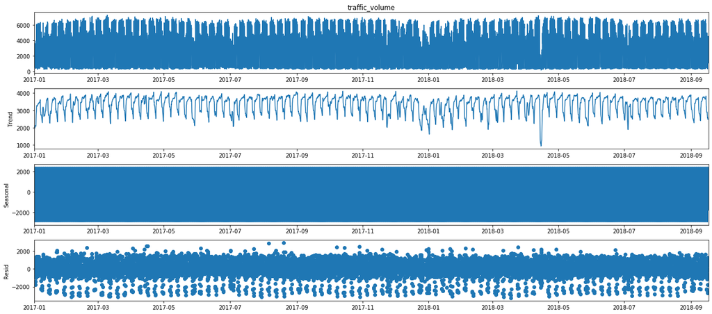

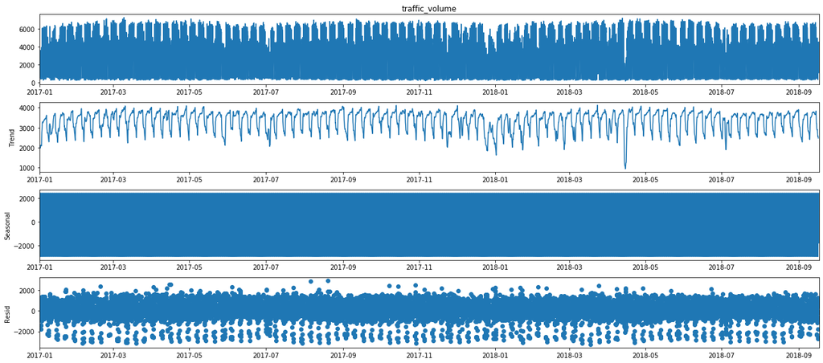

```python
import statsmodels.api as sm
decomposition = sm.tsa.seasonal_decompose(y_train, model='additive')
decomposition.plot()
```

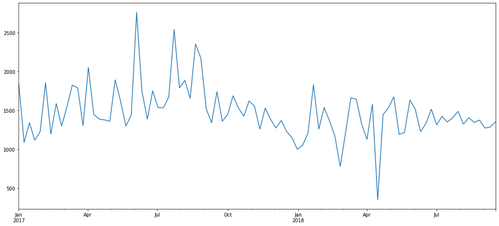

```python
y_train[::24*7].plot()
```

```python
X_train = X_train[X_train.index>'2017-09-01 00:00:00']
y_train = y_train[y_train.index>'2017-09-01 00:00:00']
```

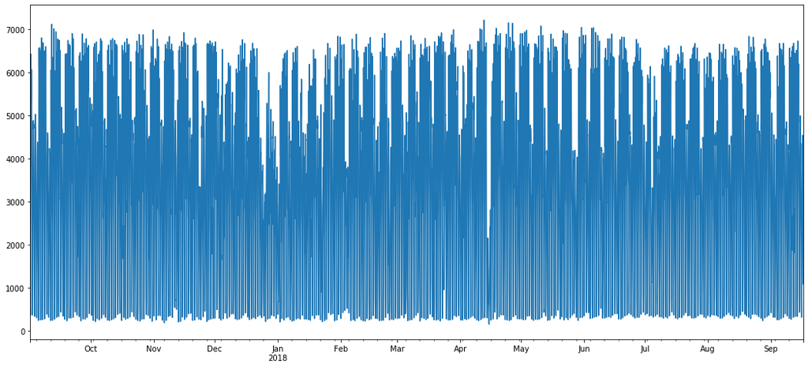

```python
y_train.plot()
```

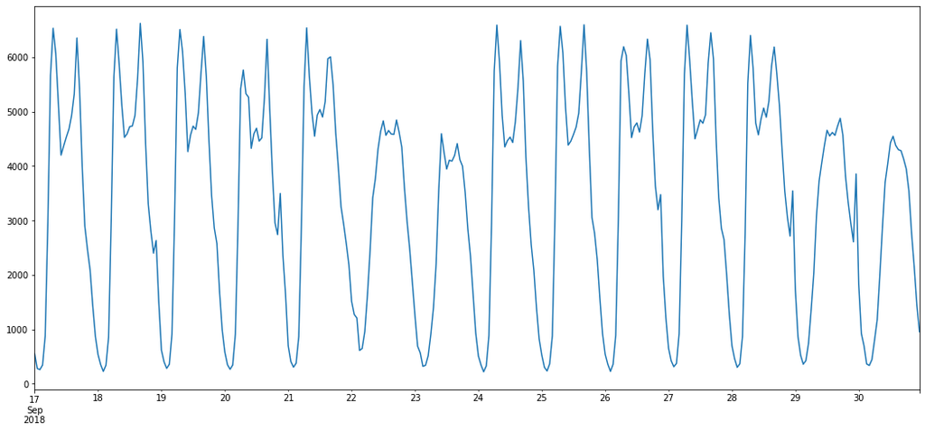

```python
y_test.plot()
```

### 2.4 Building baseline

```python
from sklearn.metrics import r2_score, mean_absolute_error, mean_squared_error

def mean_absolute_percentage_error(y_true, y_pred):
    return np.mean(np.abs((y_true - y_pred) / y_true)) * 100

models_scoring = pd.DataFrame({"Parameter":["R2", "MAE", "MSE", "MAPE"]})

def add_scoring(name, true_y, prediction_y, table=models_scoring):
    r2 = r2_score(true_y, prediction_y)
    mae = mean_absolute_error(true_y, prediction_y)
    mse = mean_squared_error(true_y, prediction_y)
    mape = mean_absolute_percentage_error(true_y, prediction_y)
    table[name] = pd.Series([r2, mae, mse, mape])
```

```python
baseline = data[data.index>'2017-09-01 00:00:00'].groupby(["weekday", "hour"])["traffic_volume"].mean()
y_pred = X_test.apply(lambda row: baseline[row['weekday']][row['hour']], axis=1)
```

```python
add_scoring('baseline', y_test, y_pred)
```

```python
models_scoring
```

|  | Parameter | baseline |
| --- | --- | --- |
| 0 | R2 | 0.978341 |
| 1 | MAE | 193.218566 |
| 2 | MSE | 83440.926199 |
| 3 | MAPE | 7.555620 |

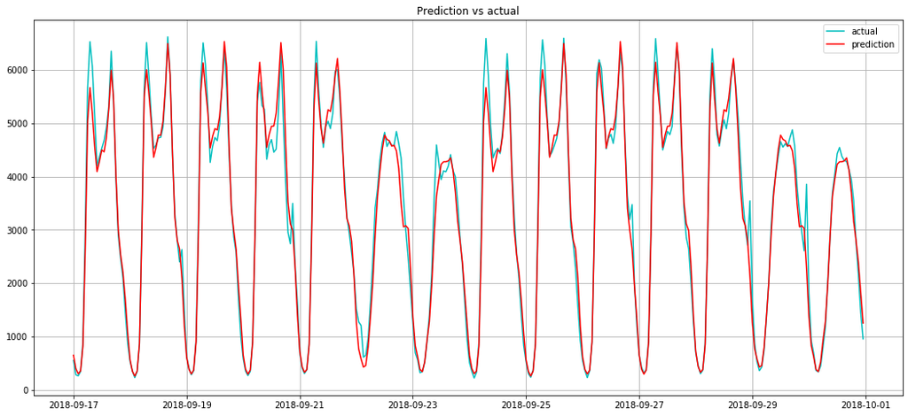

```python
def plot_predictions(pred, test=y_test, title='Prediction vs actual'):
    plt.figure()
    plt.plot(test, "c", label="actual")
    plt.plot(pred, "r", label = "prediction")
    plt.legend(loc="best")
    plt.axis('tight')
    plt.title(title)
    plt.grid(True);

plot_predictions(y_pred)
```

## 3. Modeling

### 3.1 Holt-Winters model

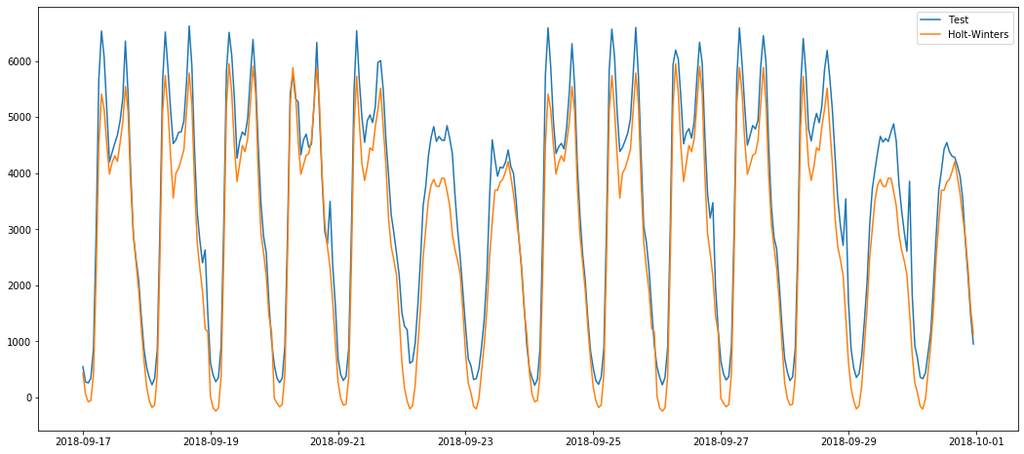

```python
from statsmodels.tsa.holtwinters import ExponentialSmoothing

model = ExponentialSmoothing(y_train[y_train.index>='2018-08-01 00:00:00'], seasonal='add', seasonal_periods=24*7).fit()
y_pred = model.predict(start=y_test.index[0], end=y_test.index[-1])

# plt.plot(y_train.index, y_train, label='Train')
plt.plot(y_test.index, y_test, label='Test')
plt.plot(y_pred.index, y_pred, label='Holt-Winters')
plt.legend(loc='best')
```

```python
add_scoring('Holt-Winters', y_test, y_pred)
models_scoring
```

|  | Parameter | baseline | Holt-Winters |
| --- | --- | --- | --- |
| 0 | R2 | 0.978341 | 0.900426 |
| 1 | MAE | 193.218566 | 541.732559 |
| 2 | MSE | 83440.926199 | 383606.681808 |
| 3 | MAPE | 7.555620 | 34.332167 |

Интересно, что Holt-Winters почти во всех точках показывает значения ниже. Если искуственно прибавить ко всем предсказаниям значение MAE, формальные показатели становятся существенно лучше. Что, однако, не дает гарантии, что они будут лучше и в дальнейшем

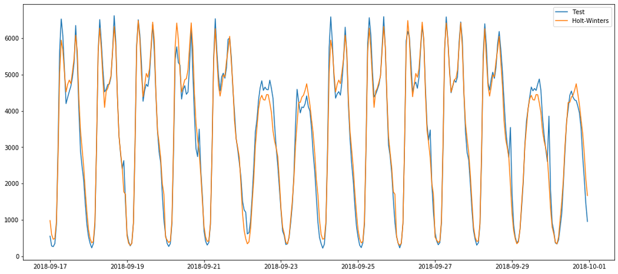

```python
plt.plot(y_test.index, y_test, label='Test')
plt.plot(y_pred.index, y_pred+540, label='Holt-Winters')
plt.legend(loc='best')
```

```python
add_scoring('Holt-Winters+MAE', y_test, y_pred+540)
models_scoring
```

|  | Parameter | baseline | Holt-Winters | Holt-Winters+MAE |
| --- | --- | --- | --- | --- |
| 0 | R2 | 0.978341 | 0.900426 | 0.973595 |
| 1 | MAE | 193.218566 | 541.732559 | 226.675626 |
| 2 | MSE | 83440.926199 | 383606.681808 | 101726.637426 |
| 3 | MAPE | 7.555620 | 34.332167 | 11.960868 |

```python
models_scoring.drop('Holt-Winters+MAE', axis=1, inplace=True)
```

### 3.2 SARIMA

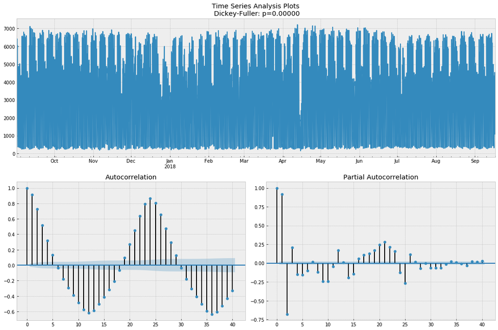

```python
import statsmodels.formula.api as smf            # statistics and econometrics
import statsmodels.tsa.api as smt
import scipy.stats as scs

def tsplot(y, lags=None, figsize=(15, 10), style='bmh'):
    """
        Plot time series, its ACF and PACF, calculate Dickey–Fuller test

        y - timeseries
        lags - how many lags to include in ACF, PACF calculation
    """
    if not isinstance(y, pd.Series):
        y = pd.Series(y)

    with plt.style.context(style):
        fig = plt.figure(figsize=figsize)
        layout = (2, 2)
        ts_ax = plt.subplot2grid(layout, (0, 0), colspan=2)
        acf_ax = plt.subplot2grid(layout, (1, 0))
        pacf_ax = plt.subplot2grid(layout, (1, 1))

        y.plot(ax=ts_ax)
        p_value = sm.tsa.stattools.adfuller(y)[1]
        ts_ax.set_title('Time Series Analysis Plots\n Dickey-Fuller: p={0:.5f}'.format(p_value))
        smt.graphics.plot_acf(y, lags=lags, ax=acf_ax)
        smt.graphics.plot_pacf(y, lags=lags, ax=pacf_ax, method="ols")
        plt.tight_layout()

tsplot(y_train)
```

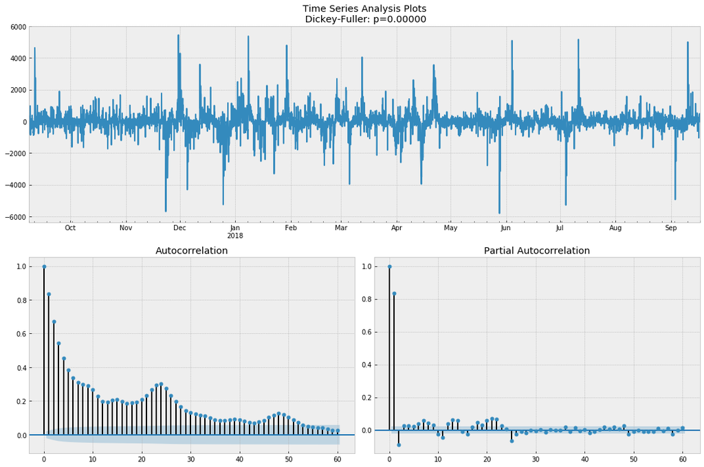

```python
y_diff = y_train - y_train.shift(24*7)
tsplot(y_diff[24*7:], lags=60)
```

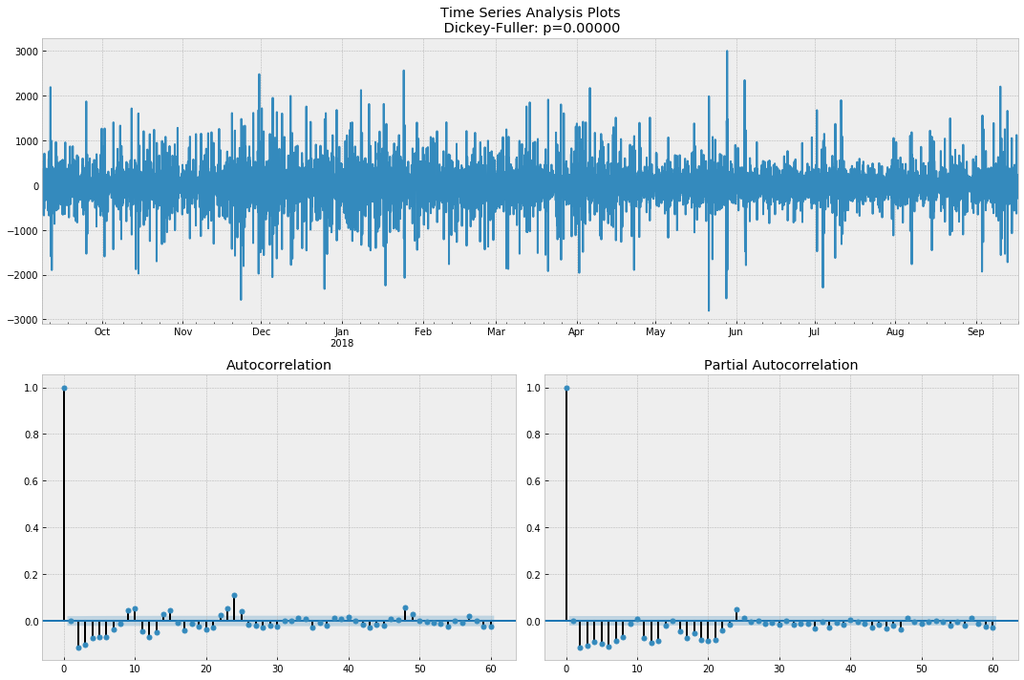

```python
y_diff = y_diff - y_diff.shift(1)
tsplot(y_diff[24*7+1:], lags=60)
```

```python
# best_model=sm.tsa.statespace.SARIMAX(y_train, order=(4, 1, 2),
#                                         seasonal_order=(2, 1, 1, 24*7)).fit(disp=-1)
```

К сожалению, модель SARIMA так и не удалось обсчитать (не говоря уже о подборе параметров), несмотря на 32ГБ ОЗУ, в результате почти суток работы я получаю out-of-memory

### 3.3 Linear regression (+ adding new features)

```python
df = data.copy()
df.drop('temp', axis=1, inplace=True)

for i in range(2*24*7, 3*24*7+1):
    df["lag_{}".format(i)] = df.traffic_volume.shift(i)
df.dropna(inplace=True)

df.drop(df[df.index<'2017-09-01 00:00:00'].index, axis=0, inplace=True)
```

```python
df
```

|  | traffic_volume | is_holiday | hour | weekday | is_weekend | lag_336 | lag_337 | lag_338 | lag_339 | lag_340 | ... | lag_495 | lag_496 | lag_497 | lag_498 | lag_499 | lag_500 | lag_501 | lag_502 | lag_503 | lag_504 |
| --- | --- | --- | --- | --- | --- | --- | --- | --- | --- | --- | --- | --- | --- | --- | --- | --- | --- | --- | --- | --- | --- |
| 2017-09-01 00:00:00 | 808.0 | 0 | 0 | 4 | 0 | 817.0 | 1483.0 | 2547.0 | 2844.0 | 3414.0 | ... | 4694.0 | 5367.0 | 6038.0 | 5356.0 | 2795.0 | 894.0 | 409.0 | 341.0 | 431.0 | 715.0 |
| 2017-09-01 01:00:00 | 520.0 | 0 | 1 | 4 | 0 | 494.0 | 817.0 | 1483.0 | 2547.0 | 2844.0 | ... | 4764.0 | 4694.0 | 5367.0 | 6038.0 | 5356.0 | 2795.0 | 894.0 | 409.0 | 341.0 | 431.0 |
| 2017-09-01 02:00:00 | 357.0 | 0 | 2 | 4 | 0 | 341.0 | 494.0 | 817.0 | 1483.0 | 2547.0 | ... | 4991.0 | 4764.0 | 4694.0 | 5367.0 | 6038.0 | 5356.0 | 2795.0 | 894.0 | 409.0 | 341.0 |
| 2017-09-01 03:00:00 | 369.0 | 0 | 3 | 4 | 0 | 370.0 | 341.0 | 494.0 | 817.0 | 1483.0 | ... | 5428.0 | 4991.0 | 4764.0 | 4694.0 | 5367.0 | 6038.0 | 5356.0 | 2795.0 | 894.0 | 409.0 |
| 2017-09-01 04:00:00 | 853.0 | 0 | 4 | 4 | 0 | 881.0 | 370.0 | 341.0 | 494.0 | 817.0 | ... | 5402.0 | 5428.0 | 4991.0 | 4764.0 | 4694.0 | 5367.0 | 6038.0 | 5356.0 | 2795.0 | 894.0 |
| ... | ... | ... | ... | ... | ... | ... | ... | ... | ... | ... | ... | ... | ... | ... | ... | ... | ... | ... | ... | ... | ... |
| 2018-09-30 19:00:00 | 3543.0 | 0 | 19 | 6 | 1 | 3400.0 | 3701.0 | 4154.0 | 4539.0 | 4101.0 | ... | 861.0 | 329.0 | 286.0 | 303.0 | 534.0 | 996.0 | 1534.0 | 2140.0 | 2755.0 | 3258.0 |
| 2018-09-30 20:00:00 | 2781.0 | 0 | 20 | 6 | 1 | 3092.0 | 3400.0 | 3701.0 | 4154.0 | 4539.0 | ... | 2963.0 | 861.0 | 329.0 | 286.0 | 303.0 | 534.0 | 996.0 | 1534.0 | 2140.0 | 2755.0 |
| 2018-09-30 21:00:00 | 2159.0 | 0 | 21 | 6 | 1 | 2623.0 | 3092.0 | 3400.0 | 3701.0 | 4154.0 | ... | 5721.0 | 2963.0 | 861.0 | 329.0 | 286.0 | 303.0 | 534.0 | 996.0 | 1534.0 | 2140.0 |
| 2018-09-30 22:00:00 | 1450.0 | 0 | 22 | 6 | 1 | 1725.0 | 2623.0 | 3092.0 | 3400.0 | 3701.0 | ... | 6561.0 | 5721.0 | 2963.0 | 861.0 | 329.0 | 286.0 | 303.0 | 534.0 | 996.0 | 1534.0 |
| 2018-09-30 23:00:00 | 954.0 | 0 | 23 | 6 | 1 | 1088.0 | 1725.0 | 2623.0 | 3092.0 | 3400.0 | ... | 6009.0 | 6561.0 | 5721.0 | 2963.0 | 861.0 | 329.0 | 286.0 | 303.0 | 534.0 | 996.0 |

9480 rows × 174 columns

```python
target = 'traffic_volume'
separator = '2018-09-17 00:00:00'

day = pd.get_dummies(df['weekday'], prefix='day')
df = pd.concat([df, day], axis=1)
df.drop('weekday', axis=1, inplace=True)

hour = pd.get_dummies(df['hour'], prefix='hour')
df = pd.concat([df, hour], axis=1)
df.drop('hour', axis=1, inplace=True)


X_train = df.loc[df.index < separator, df.columns != target]
y_train = df[df.index<separator][target]
X_test = df.loc[df.index >= separator, df.columns != target]
y_test = df[df.index>=separator][target]
```

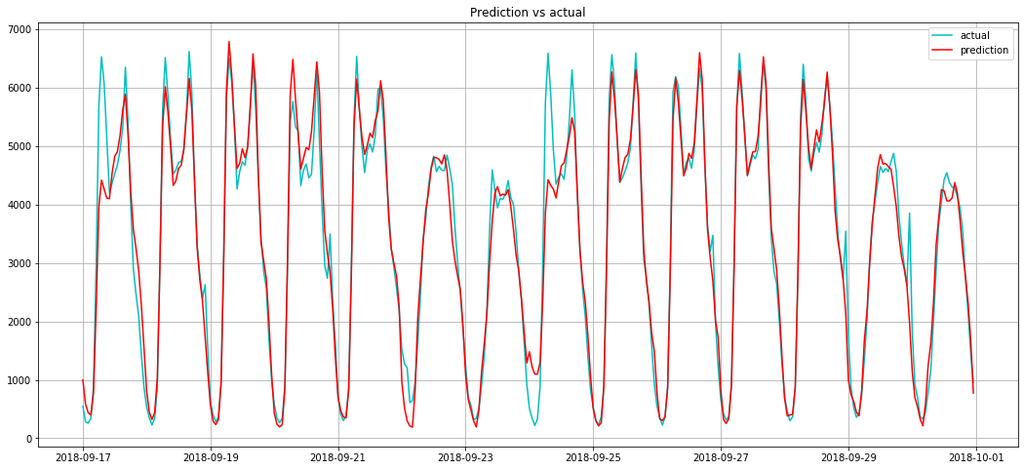

```python
from sklearn.linear_model import LinearRegression
from sklearn.preprocessing import StandardScaler

scaler = StandardScaler()
X_train_scaled = scaler.fit_transform(X_train)
X_test_scaled = scaler.transform(X_test)

lr = LinearRegression()
lr.fit(X_train_scaled, y_train)
y_pred = pd.Series(lr.predict(X_test_scaled), index=y_test.index)
plot_predictions(y_pred, y_test)
```

```python
add_scoring('Linear Regression', y_test, y_pred)
models_scoring
```

|  | Parameter | baseline | Holt-Winters | Linear Regression |
| --- | --- | --- | --- | --- |
| 0 | R2 | 0.978341 | 0.900426 | 0.954020 |
| 1 | MAE | 193.218566 | 541.732559 | 265.703629 |
| 2 | MSE | 83440.926199 | 383606.681808 | 177138.989962 |
| 3 | MAPE | 7.555620 | 34.332167 | 14.954231 |

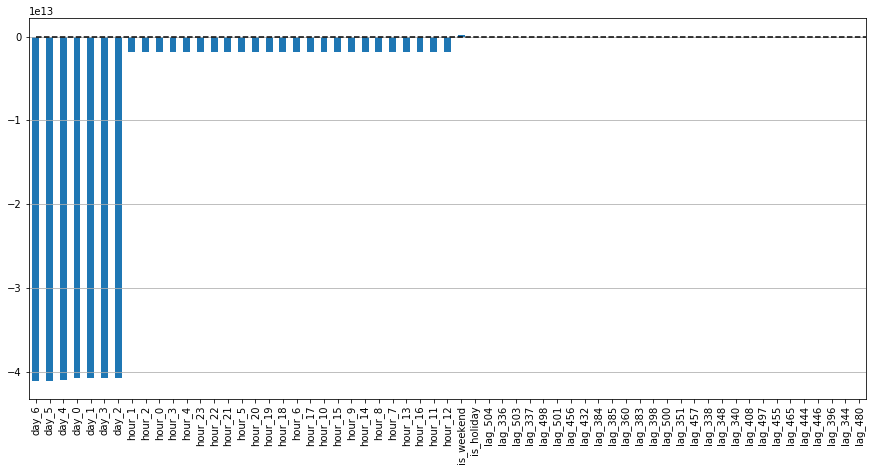

```python
def plotCoefficients(model, threshhold=50):
    """
        Plots sorted coefficient values of the model
    """

    coefs = pd.DataFrame(model.coef_, X_train.columns)
    coefs.columns = ["coef"]
    coefs["abs"] = coefs.coef.apply(np.abs)
    coefs = coefs.sort_values(by="abs", ascending=False).drop(["abs"], axis=1)

    plt.figure(figsize=(15, 7))
    coefs[abs(coefs.coef)>threshhold].coef.plot(kind='bar')
    plt.grid(True, axis='y')
    plt.hlines(y=0, xmin=0, xmax=len(coefs), linestyles='dashed');

plotCoefficients(lr)
```

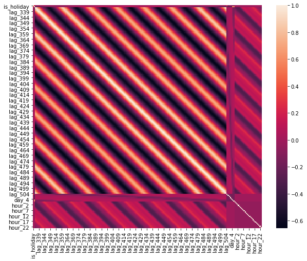

```python
plt.figure(figsize=(10, 8))
sns.heatmap(X_train.corr());
```

```python
from sklearn.model_selection import cross_val_score, TimeSeriesSplit

tscv = TimeSeriesSplit(n_splits=5)

from sklearn.linear_model import LassoCV, RidgeCV

ridge = RidgeCV(cv=tscv, alphas=np.linspace(1, 15))
ridge.fit(X_train_scaled, y_train);
```

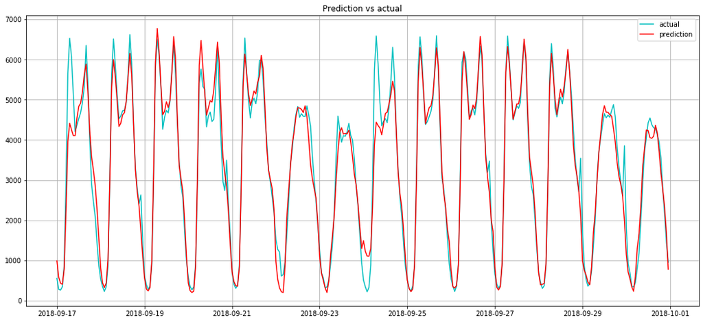

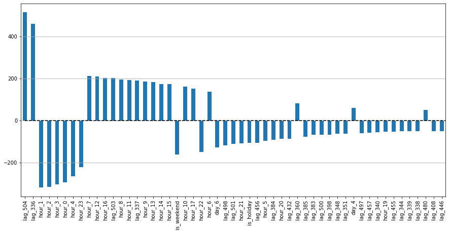

```python
y_pred = pd.Series(ridge.predict(X_test_scaled), index=y_test.index)
plot_predictions(y_pred, y_test)
plotCoefficients(ridge, 50)
```

```python
add_scoring('Ridge', y_test, y_pred)
models_scoring
```

|  | Parameter | baseline | Holt-Winters | Linear Regression | Ridge |
| --- | --- | --- | --- | --- | --- |
| 0 | R2 | 0.978341 | 0.900426 | 0.954020 | 0.954210 |
| 1 | MAE | 193.218566 | 541.732559 | 265.703629 | 263.910713 |
| 2 | MSE | 83440.926199 | 383606.681808 | 177138.989962 | 176404.610541 |
| 3 | MAPE | 7.555620 | 34.332167 | 14.954231 | 14.840999 |

```python
lasso = LassoCV(cv=tscv, eps=0.005)
lasso.fit(X_train_scaled, y_train);
```

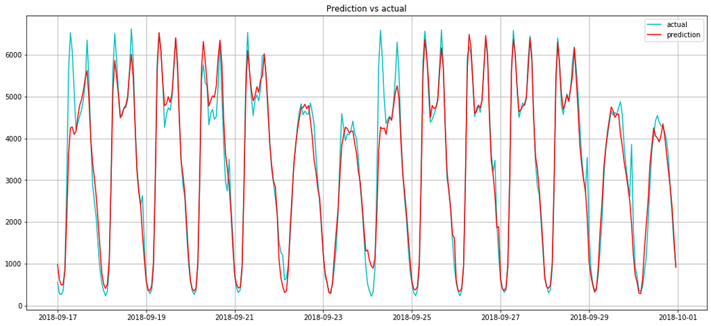

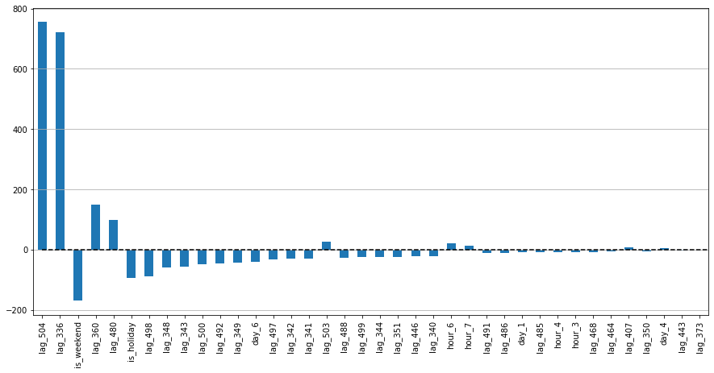

```python
y_pred = pd.Series(lasso.predict(X_test_scaled), index=y_test.index)
plot_predictions(y_pred, y_test)
plotCoefficients(lasso, 1)
```

```python
add_scoring('Lasso', y_test, y_pred)
models_scoring
```

|  | Parameter | baseline | Holt-Winters | Linear Regression | Ridge | Lasso |
| --- | --- | --- | --- | --- | --- | --- |
| 0 | R2 | 0.978341 | 0.900426 | 0.954020 | 0.954210 | 0.951296 |
| 1 | MAE | 193.218566 | 541.732559 | 265.703629 | 263.910713 | 263.468950 |
| 2 | MSE | 83440.926199 | 383606.681808 | 177138.989962 | 176404.610541 | 187633.341990 |
| 3 | MAPE | 7.555620 | 34.332167 | 14.954231 | 14.840999 | 14.600197 |

Выделим несколько наиболее важных фич и обучим модельку на них

```python
X_train_new = X_train.loc[:,['lag_504', 'lag_336', 'is_weekend', 'lag_360', 'lag_480']]
X_test_new = X_test.loc[:,['lag_504', 'lag_336', 'is_weekend', 'lag_360', 'lag_480']]
scaler = StandardScaler()
X_train_scaled_new = scaler.fit_transform(X_train_new)
X_test_scaled_new = scaler.transform(X_test_new)
```

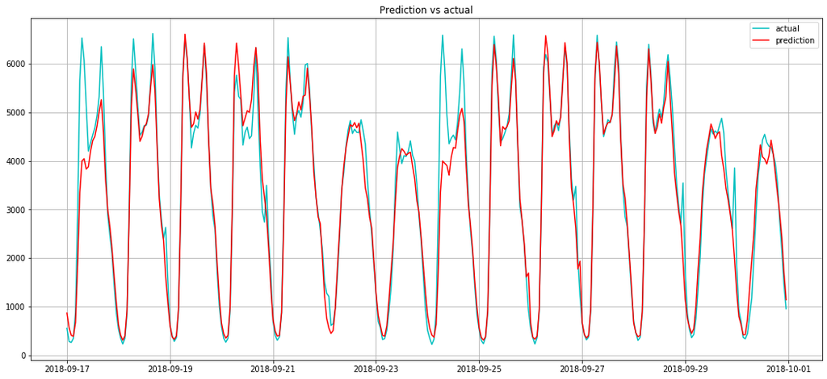

```python
lasso = LassoCV(cv=tscv, eps=0.005)
lasso.fit(X_train_new, y_train)
y_pred = pd.Series(lasso.predict(X_test_new), index=y_test.index)
plot_predictions(y_pred, y_test)
```

```python
add_scoring('Lasso_reduced', y_test, y_pred)
models_scoring
```

|  | Parameter | baseline | Holt-Winters | Linear Regression | Ridge | Lasso | Lasso_reduced |
| --- | --- | --- | --- | --- | --- | --- | --- |
| 0 | R2 | 0.978341 | 0.900426 | 0.954020 | 0.954210 | 0.951296 | 0.943746 |
| 1 | MAE | 193.218566 | 541.732559 | 265.703629 | 263.910713 | 263.468950 | 267.585586 |
| 2 | MSE | 83440.926199 | 383606.681808 | 177138.989962 | 176404.610541 | 187633.341990 | 216715.994499 |
| 3 | MAPE | 7.555620 | 34.332167 | 14.954231 | 14.840999 | 14.600197 | 11.525889 |

### 3.4 Boosting

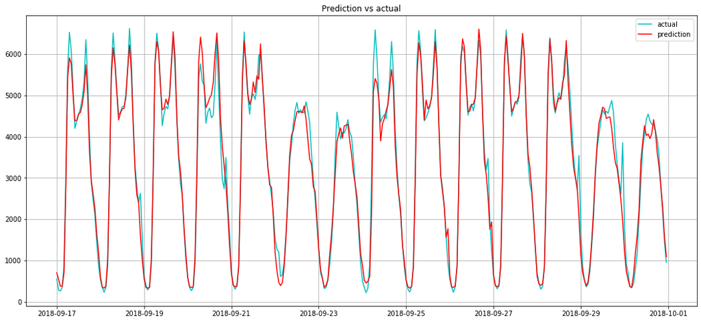

```python
from sklearn.ensemble import GradientBoostingRegressor, AdaBoostRegressor

gbr = GradientBoostingRegressor(n_estimators=150)
gbr.fit(X_train_scaled, y_train)
y_pred = pd.Series(gbr.predict(X_test_scaled), index=y_test.index)
plot_predictions(y_pred, y_test)
```

```python
add_scoring('GradientBoosting', y_test, y_pred)
models_scoring
```

|  | Parameter | baseline | Holt-Winters | Linear Regression | Ridge | Lasso | Lasso_reduced | GradientBoosting |
| --- | --- | --- | --- | --- | --- | --- | --- | --- |
| 0 | R2 | 0.978341 | 0.900426 | 0.954020 | 0.954210 | 0.951296 | 0.943746 | 0.974243 |
| 1 | MAE | 193.218566 | 541.732559 | 265.703629 | 263.910713 | 263.468950 | 267.585586 | 208.069361 |
| 2 | MSE | 83440.926199 | 383606.681808 | 177138.989962 | 176404.610541 | 187633.341990 | 216715.994499 | 99228.772394 |
| 3 | MAPE | 7.555620 | 34.332167 | 14.954231 | 14.840999 | 14.600197 | 11.525889 | 9.812641 |

Оптимизируем параметры бустинга

```python
from hyperopt import hp, tpe
from hyperopt.fmin import fmin

def objective(params):
    params = {'n_estimators': int(params['n_estimators']), 'max_depth': int(params['max_depth']),
             'subsample': float(params['subsample'])}
    clf = GradientBoostingRegressor(**params)
    clf.fit(X_train_scaled, y_train)
#     score = cross_val_score(clf, X, y, scoring='f1').mean()
    y_pred = pd.Series(clf.predict(X_test_scaled), index=y_test.index)
    score = mean_absolute_percentage_error(y_test, y_pred)
    print("F1 {:.3f} params {}".format(score, params))
    return score

space = {
    'n_estimators': hp.quniform('n_estimators', 50, 500, 25),
    'max_depth': hp.quniform('max_depth', 1, 10, 1),
    'subsample': hp.quniform('subsample', 0.1, 1, 0.1),
}


best = fmin(fn=objective,
            space=space,
            algo=tpe.suggest,
            max_evals=50)
```

[output not shown]

```
F1 9.941 params {'n_estimators': 275, 'max_depth': 9, 'subsample': 0.2}
```

[output not shown]

```
F1 9.286 params {'n_estimators': 375, 'max_depth': 5, 'subsample': 0.4}
```

[output not shown]

```
F1 8.379 params {'n_estimators': 475, 'max_depth': 9, 'subsample': 0.7000000000000001}
```

[output not shown]

```
F1 9.292 params {'n_estimators': 150, 'max_depth': 6, 'subsample': 0.5}
```

[output not shown]

```
F1 9.262 params {'n_estimators': 375, 'max_depth': 4, 'subsample': 0.5}
```

[output not shown]

```
F1 10.377 params {'n_estimators': 75, 'max_depth': 4, 'subsample': 0.30000000000000004}
```

[output not shown]

```
F1 10.559 params {'n_estimators': 275, 'max_depth': 2, 'subsample': 0.5}
```

[output not shown]

```
F1 9.933 params {'n_estimators': 250, 'max_depth': 4, 'subsample': 0.2}
```

[output not shown]

```
F1 9.968 params {'n_estimators': 200, 'max_depth': 6, 'subsample': 0.2}
```

[output not shown]

```
F1 8.210 params {'n_estimators': 450, 'max_depth': 9, 'subsample': 0.6000000000000001}
```

[output not shown]

```
F1 8.692 params {'n_estimators': 75, 'max_depth': 7, 'subsample': 0.8}
```

[output not shown]

```
F1 9.973 params {'n_estimators': 50, 'max_depth': 5, 'subsample': 0.9}
```

[output not shown]

```
F1 9.728 params {'n_estimators': 475, 'max_depth': 3, 'subsample': 0.5}
```

[output not shown]

```
F1 9.041 params {'n_estimators': 450, 'max_depth': 6, 'subsample': 0.6000000000000001}
```

[output not shown]

```
F1 9.796 params {'n_estimators': 200, 'max_depth': 10, 'subsample': 0.2}
```

[output not shown]

```
F1 8.749 params {'n_estimators': 150, 'max_depth': 6, 'subsample': 0.7000000000000001}
```

[output not shown]

```
F1 11.189 params {'n_estimators': 75, 'max_depth': 2, 'subsample': 0.9}
```

[output not shown]

```
F1 8.254 params {'n_estimators': 125, 'max_depth': 9, 'subsample': 0.5}
```

[output not shown]

```
F1 8.641 params {'n_estimators': 450, 'max_depth': 9, 'subsample': 0.4}
```

[output not shown]

```
F1 9.658 params {'n_estimators': 450, 'max_depth': 2, 'subsample': 0.9}
```

[output not shown]

```
F1 8.121 params {'n_estimators': 350, 'max_depth': 8, 'subsample': 0.7000000000000001}
```

[output not shown]

```
F1 8.284 params {'n_estimators': 375, 'max_depth': 8, 'subsample': 0.7000000000000001}
```

[output not shown]

```
F1 8.405 params {'n_estimators': 325, 'max_depth': 8, 'subsample': 0.8}
```

[output not shown]

```
F1 8.276 params {'n_estimators': 400, 'max_depth': 10, 'subsample': 0.6000000000000001}
```

[output not shown]

```
F1 8.198 params {'n_estimators': 325, 'max_depth': 8, 'subsample': 1.0}
```

[output not shown]

```
F1 8.634 params {'n_estimators': 325, 'max_depth': 7, 'subsample': 0.8}
```

[output not shown]

```
F1 8.236 params {'n_estimators': 325, 'max_depth': 8, 'subsample': 1.0}
```

[output not shown]

```
F1 8.789 params {'n_estimators': 300, 'max_depth': 7, 'subsample': 0.9}
```

[output not shown]

```
F1 8.315 params {'n_estimators': 225, 'max_depth': 10, 'subsample': 1.0}
```

[output not shown]

```
F1 8.192 params {'n_estimators': 400, 'max_depth': 8, 'subsample': 1.0}
```

[output not shown]

```
F1 8.601 params {'n_estimators': 400, 'max_depth': 7, 'subsample': 0.8}
```

[output not shown]

```
F1 11.300 params {'n_estimators': 500, 'max_depth': 8, 'subsample': 0.1}
```

[output not shown]

```
F1 8.754 params {'n_estimators': 400, 'max_depth': 10, 'subsample': 0.4}
```

[output not shown]

```
F1 9.147 params {'n_estimators': 350, 'max_depth': 5, 'subsample': 0.7000000000000001}
```

[output not shown]

```
F1 7.867 params {'n_estimators': 425, 'max_depth': 9, 'subsample': 1.0}
```

[output not shown]

```
F1 8.269 params {'n_estimators': 500, 'max_depth': 9, 'subsample': 0.30000000000000004}
```

[output not shown]

```
F1 8.689 params {'n_estimators': 275, 'max_depth': 10, 'subsample': 0.7000000000000001}
```

[output not shown]

```
F1 9.265 params {'n_estimators': 425, 'max_depth': 7, 'subsample': 0.30000000000000004}
```

[output not shown]

```
F1 8.720 params {'n_estimators': 350, 'max_depth': 9, 'subsample': 0.6000000000000001}
```

[output not shown]

```
F1 8.304 params {'n_estimators': 300, 'max_depth': 9, 'subsample': 0.8}
```

[output not shown]

```
F1 8.586 params {'n_estimators': 250, 'max_depth': 6, 'subsample': 0.9}
```

[output not shown]

```
F1 10.078 params {'n_estimators': 475, 'max_depth': 3, 'subsample': 0.4}
```

[output not shown]

```
F1 11.238 params {'n_estimators': 425, 'max_depth': 5, 'subsample': 0.1}
```

[output not shown]

```
F1 9.294 params {'n_estimators': 375, 'max_depth': 4, 'subsample': 0.6000000000000001}
```

[output not shown]

```
F1 9.159 params {'n_estimators': 350, 'max_depth': 7, 'subsample': 0.5}
```

[output not shown]

```
F1 8.657 params {'n_estimators': 475, 'max_depth': 10, 'subsample': 0.7000000000000001}
```

[output not shown]

```
F1 8.710 params {'n_estimators': 175, 'max_depth': 6, 'subsample': 1.0}
```

[output not shown]

```
F1 8.082 params {'n_estimators': 425, 'max_depth': 9, 'subsample': 0.8}
```

[output not shown]

```
F1 9.294 params {'n_estimators': 500, 'max_depth': 3, 'subsample': 0.9}
```

[output not shown]

```
F1 8.413 params {'n_estimators': 425, 'max_depth': 9, 'subsample': 0.8}
```

```python
best
```

```
{'max_depth': 9.0, 'n_estimators': 425.0, 'subsample': 1.0}
```

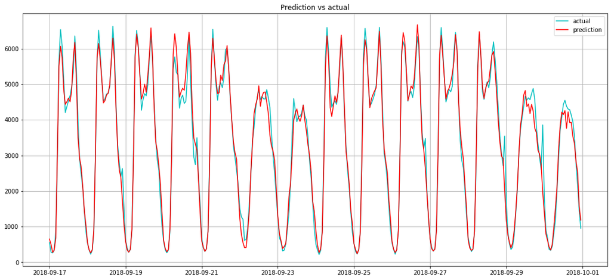

```python
gbr = GradientBoostingRegressor(n_estimators=425,
                                max_depth=9,
                                subsample=1.0
                                )
gbr.fit(X_train_scaled, y_train)
y_pred = pd.Series(gbr.predict(X_test_scaled), index=y_test.index)
plot_predictions(y_pred, y_test)
```

```python
add_scoring('GradientBoosting', y_test, y_pred)
models_scoring
```

|  | Parameter | baseline | Holt-Winters | Linear Regression | Ridge | Lasso | Lasso_reduced | GradientBoosting |
| --- | --- | --- | --- | --- | --- | --- | --- | --- |
| 0 | R2 | 0.978341 | 0.900426 | 0.954020 | 0.954210 | 0.951296 | 0.943746 | 0.979533 |
| 1 | MAE | 193.218566 | 541.732559 | 265.703629 | 263.910713 | 263.468950 | 267.585586 | 188.910650 |
| 2 | MSE | 83440.926199 | 383606.681808 | 177138.989962 | 176404.610541 | 187633.341990 | 216715.994499 | 78850.762122 |
| 3 | MAPE | 7.555620 | 34.332167 | 14.954231 | 14.840999 | 14.600197 | 11.525889 | 8.002352 |

### 3.5 Facebook Prophet

```python
# !conda install fbprophet
```

```python
from fbprophet import Prophet
```

```python
# number of future predictions
predictions = 24*7*2

# creating a specific format dataset
df = data.copy()
df.drop(['temp', 'is_holiday', 'hour', 'weekday', 'is_weekend'], axis=1, inplace=True)
df.reset_index(inplace=True)
```

```python
df.columns = ['ds', 'y']
```

```python
train_df = df[:-predictions]

model = Prophet(weekly_seasonality=True, yearly_seasonality=False)
model.fit(train_df)

future = model.make_future_dataframe(periods=predictions, freq='H')
future.tail()
```

|  | ds |
| --- | --- |
| 15307 | 2018-09-30 19:00:00 |
| 15308 | 2018-09-30 20:00:00 |
| 15309 | 2018-09-30 21:00:00 |
| 15310 | 2018-09-30 22:00:00 |
| 15311 | 2018-09-30 23:00:00 |

```python
forecast = model.predict(future)
forecast.head()
```

|  | ds | trend | yhat_lower | yhat_upper | trend_lower | trend_upper | additive_terms | additive_terms_lower | additive_terms_upper | daily | daily_lower | daily_upper | weekly | weekly_lower | weekly_upper | multiplicative_terms | multiplicative_terms_lower | multiplicative_terms_upper | yhat |
| --- | --- | --- | --- | --- | --- | --- | --- | --- | --- | --- | --- | --- | --- | --- | --- | --- | --- | --- | --- |
| 0 | 2017-01-01 00:00:00 | 3090.551398 | -990.220314 | 1194.955045 | 3090.551398 | 3090.551398 | -2955.889420 | -2955.889420 | -2955.889420 | -2170.391994 | -2170.391994 | -2170.391994 | -785.497427 | -785.497427 | -785.497427 | 0.0 | 0.0 | 0.0 | 134.661978 |
| 1 | 2017-01-01 01:00:00 | 3090.782370 | -1667.757691 | 506.730050 | 3090.782370 | 3090.782370 | -3656.794235 | -3656.794235 | -3656.794235 | -2864.211135 | -2864.211135 | -2864.211135 | -792.583101 | -792.583101 | -792.583101 | 0.0 | 0.0 | 0.0 | -566.011866 |
| 2 | 2017-01-01 02:00:00 | 3091.013341 | -2148.650060 | 38.560418 | 3091.013341 | 3091.013341 | -4107.064783 | -4107.064783 | -4107.064783 | -3310.382713 | -3310.382713 | -3310.382713 | -796.682071 | -796.682071 | -796.682071 | 0.0 | 0.0 | 0.0 | -1016.051442 |
| 3 | 2017-01-01 03:00:00 | 3091.244313 | -1893.688864 | 330.934863 | 3091.244313 | 3091.244313 | -3927.323456 | -3927.323456 | -3927.323456 | -3129.515857 | -3129.515857 | -3129.515857 | -797.807599 | -797.807599 | -797.807599 | 0.0 | 0.0 | 0.0 | -836.079143 |
| 4 | 2017-01-01 04:00:00 | 3091.475284 | -986.726234 | 1212.410713 | 3091.475284 | 3091.475284 | -3013.859989 | -3013.859989 | -3013.859989 | -2217.866779 | -2217.866779 | -2217.866779 | -795.993210 | -795.993210 | -795.993210 | 0.0 | 0.0 | 0.0 | 77.615295 |

```python
y_pred = pd.Series(forecast[-predictions:]['yhat'])
y_pred.index =forecast[-predictions:]['ds']
```

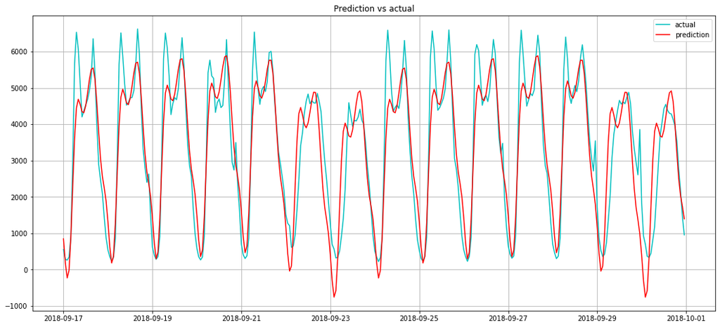

```python
plot_predictions(y_pred, y_test)
```

```python
add_scoring('fbProphet', y_test, y_pred)
models_scoring
```

|  | Parameter | baseline | Holt-Winters | Linear Regression | Ridge | Lasso | Lasso_reduced | GradientBoosting | fbProphet |
| --- | --- | --- | --- | --- | --- | --- | --- | --- | --- |
| 0 | R2 | 0.978341 | 0.900426 | 0.954020 | 0.954210 | 0.951296 | 0.943746 | 0.979533 | 0.832230 |
| 1 | MAE | 193.218566 | 541.732559 | 265.703629 | 263.910713 | 263.468950 | 267.585586 | 188.910650 | 597.101150 |
| 2 | MSE | 83440.926199 | 383606.681808 | 177138.989962 | 176404.610541 | 187633.341990 | 216715.994499 | 78850.762122 | 646332.015005 |
| 3 | MAPE | 7.555620 | 34.332167 | 14.954231 | 14.840999 | 14.600197 | 11.525889 | 8.002352 | 36.809833 |

## 4. Conclusion

Добиться точности прогноза, сравнимой с простейшим средним по часам+дням недели удалось только с применением градиентного бустинга. Таким образом можно сделать вывод, что для решения данной задачи достаточно пользоваться базовым прогнозом, который не требует высоких вычислительных мощностей и частого переобучения.